# Figure 3: alpha-synuclein SAA and tau PET in ADNI

felix.struebing@med.uni-muenchen.de

2026-07-09

This notebook documents the ADNI analyses used for manuscript Fig. 3d, Supplementary Table 3, and the related supplementary ADNI panels. The Fig. 3e cortical renderings and the western blot panels in Fig. 3a-c/Fig. S5 are not generated here.

# 1 Libraries and definitions

```r
library(tidyverse)
library(ggpubr)
library(emmeans)
library(patchwork)
source('resources/ggplot_theme_patchwork.R')

# Match the AD_color / ASYN_color palette used in Figure_1.Rmd
AD_color   <- ggsci::pal_igv('alternating')(2)[1]
ASYN_color <- ggsci::pal_igv('alternating')(2)[2]
saa_colors <- c(negative = AD_color, positive = ASYN_color)
```

# 2 Load ADNI data

```r
mytable <- readr::read_csv('resources/ADNI_DF_11_2022_22_11_2024.csv',
                           show_col_types = FALSE)
```

# 3 ADNI cohort definition and exclusion criteria

The analysis cohort includes ADNI participants with both CSF alpha-synuclein seed-amplification assay (SAA) status and a tau-PET superior frontal gyrus (SFG) SUVR measurement. ADNI enrollment criteria are described in the ADNI protocol and the manuscript Methods.

# 4 Analysis cohort

```r
adni <- mytable %>%
    dplyr::filter(!is.na(CSF_AlphaSyn_seeding),
                  !is.na(tau.SUVR.DK.lsuperiorfrontal)) %>%
    dplyr::transmute(
        RID,
        saa          = factor(CSF_AlphaSyn_seeding, levels = c('negative', 'positive')),
        age,
        sex          = factor(sex),
        education_yrs,
        APOE4_status = factor(APOE4_status),
        # collapse sparse categories to avoid unstable single-count cells (n = 369)
        race_bin     = factor(dplyr::if_else(race == 'white', 'white', 'non-white')),
        ethnicity    = factor(dplyr::na_if(ethnicity_hispanic, 'unkown')),
        dx           = factor(DX, levels = c('CN', 'MCI', 'Dementia')),
        amyloid_status = factor(amyloid_status),
        centiloid,
        amyloid_sfg  = amyloid.SUVR.DK.lsuperiorfrontal,
        tau_sfg      = tau.SUVR.DK.lsuperiorfrontal,
        # signed CSF-SAA to tau-PET interval (positive = PET after SAA)
        saa_tau_gap_yrs = as.numeric(difftime(EXAMDATE_tau, EXAMDATE_AlphaSyn,
                                              units = 'days')) / 365.25
    )

# one row per participant
nrow(adni); dplyr::n_distinct(adni$RID); table(adni$saa)
```

```
## [1] 369
```

```
## [1] 369
```

```
##
## negative positive
##      306       63
```

# 5 CSF-SAA to tau-PET interval

Summarise the time interval between CSF-SAA assessment and tau-PET scan:

```r
summary(adni$saa_tau_gap_yrs)
```

```
##     Min.  1st Qu.   Median     Mean  3rd Qu.     Max.
## -0.49829 -0.02190  0.00000  0.01892  0.04107  0.66804
```

```r
summary(abs(adni$saa_tau_gap_yrs))
```

```
##    Min. 1st Qu.  Median    Mean 3rd Qu.    Max.
## 0.00000 0.01095 0.03012 0.06986 0.07940 0.66804
```

```r
# fraction acquired within 1 year of each other
mean(abs(adni$saa_tau_gap_yrs) <= 1)
```

```
## [1] 1
```

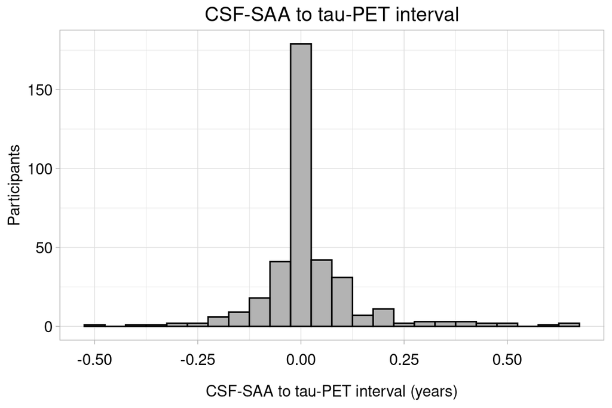

```r
p_gap <- ggplot(adni, aes(x = saa_tau_gap_yrs)) +
    geom_histogram(binwidth = 0.05, fill = 'grey70', color = 'black') +
    labs(x = 'CSF-SAA to tau-PET interval (years)',
         y = 'Participants',
         title = 'CSF-SAA to tau-PET interval') +
    theme_patch()
p_gap
```

Wilcoxon test comparing the interval by SAA group:

```r
wilcox.test(saa_tau_gap_yrs ~ saa, data = adni)
```

```
##
##  Wilcoxon rank sum test with continuity correction
##
## data:  saa_tau_gap_yrs by saa
## W = 9914.5, p-value = 0.7211
## alternative hypothesis: true location shift is not equal to 0
```

```r
pdf('figure/SFig_ADNI_interval.pdf', width = 6, height = 4)
p_gap
dev.off()
```

# 6 Demographic and clinical characteristics by SAA status

Build Supplementary Table 3. Continuous variables are compared with Wilcoxon tests; categorical variables are compared with chi-squared tests.

```r
cont_row <- function(v, lab) {
    x <- adni[[v]]
    s <- tapply(x, adni$saa, function(z) sprintf('%.1f (%.1f)', mean(z, na.rm = TRUE), sd(z, na.rm = TRUE)))
    p <- wilcox.test(x ~ adni$saa)$p.value
    data.frame(Variable = lab, `SAA-negative` = s['negative'], `SAA-positive` = s['positive'],
               p = sprintf('%.3g', p), check.names = FALSE)
}
cat_row <- function(v, lab) {
    tb    <- table(adni[[v]], adni$saa)
    p     <- suppressWarnings(chisq.test(tb)$p.value)
    props <- sweep(tb, 2, colSums(tb), '/')
    out <- data.frame(
        Variable = paste0(lab, ', ', rownames(tb)),
        `SAA-negative` = sprintf('%d (%.0f%%)', tb[, 'negative'], 100 * props[, 'negative']),
        `SAA-positive` = sprintf('%d (%.0f%%)', tb[, 'positive'], 100 * props[, 'positive']),
        p = '', check.names = FALSE)
    out$p[1] <- sprintf('%.3g', p)
    out
}

tab_s <- dplyr::bind_rows(
    data.frame(Variable = 'N', `SAA-negative` = as.character(sum(adni$saa == 'negative')),
               `SAA-positive` = as.character(sum(adni$saa == 'positive')), p = '', check.names = FALSE),
    cont_row('age',           'Age, yrs'),
    cat_row('sex',            'Sex'),
    cont_row('education_yrs', 'Education, yrs'),
    cat_row('APOE4_status',   'APOE4'),
    cat_row('race_bin',       'Race'),
    cat_row('ethnicity',      'Ethnicity'),
    cat_row('dx',             'Clinical stage'),
    cat_row('amyloid_status', 'Amyloid status'),
    cont_row('centiloid',     'Centiloid'),
    cont_row('amyloid_sfg',   'Amyloid SUVR (SFG)'),
    cont_row('tau_sfg',       'Tau SUVR (SFG)'),
    cont_row('saa_tau_gap_yrs', 'SAA-to-tauPET gap, yrs')
)
rownames(tab_s) <- NULL
knitr::kable(tab_s, caption = 'Table S: ADNI cohort characteristics by CSF alpha-synuclein SAA status. Continuous variables, mean (SD); categorical, n (%).')
```

Table S: ADNI cohort characteristics by CSF alpha-synuclein SAA status. Continuous variables, mean (SD); categorical, n (%).

| Variable | SAA-negative | SAA-positive | p |
| --- | --- | --- | --- |
| N | 306 | 63 |  |
| Age, yrs | 72.6 (7.8) | 77.0 (7.2) | 6.07e-05 |
| Sex, female | 169 (55%) | 24 (38%) | 0.0192 |
| Sex, male | 137 (45%) | 39 (62%) |  |
| Education, yrs | 16.5 (2.4) | 16.7 (2.5) | 0.608 |
| APOE4, APOE4.neg | 185 (61%) | 29 (46%) | 0.0422 |
| APOE4, APOE4.pos | 119 (39%) | 34 (54%) |  |
| Race, non-white | 30 (10%) | 5 (8%) | 0.822 |
| Race, white | 276 (90%) | 58 (92%) |  |
| Ethnicity, hispanic_latino | 13 (4%) | 1 (2%) | 0.517 |
| Ethnicity, not_hispanic_or_latino | 292 (96%) | 62 (98%) |  |
| Clinical stage, CN | 163 (53%) | 26 (41%) | 5.07e-06 |
| Clinical stage, MCI | 113 (37%) | 16 (25%) |  |
| Clinical stage, Dementia | 30 (10%) | 21 (33%) |  |
| Amyloid status, Ab.neg | 150 (54%) | 18 (31%) | 0.00209 |
| Amyloid status, Ab.pos | 130 (46%) | 41 (69%) |  |
| Centiloid | 41.9 (45.9) | 60.1 (49.9) | 0.0178 |
| Amyloid SUVR (SFG) | 1.2 (0.3) | 1.3 (0.3) | 0.0133 |
| Tau SUVR (SFG) | 1.1 (0.2) | 1.2 (0.3) | 0.0426 |
| SAA-to-tauPET gap, yrs | 0.0 (0.1) | 0.0 (0.1) | 0.721 |

```r
write_csv(tab_s, 'figure/SuppTable_3.csv')
```

```r
# readr::write_csv(tab_s, 'output/TableS_ADNI_SAA_characteristics.csv')
```

# 7 Fig. 3 — Tau PET by alpha-synuclein SAA status

Fit the manuscript ADNI tau-PET model with age, sex, education, APOE4 status, race, and ethnicity as covariates.

```r
model_adni <- lm(tau_sfg ~ saa + age + sex + education_yrs + APOE4_status +
                     race_bin + ethnicity, data = adni)
summary(model_adni)
```

```
##
## Call:
## lm(formula = tau_sfg ~ saa + age + sex + education_yrs + APOE4_status +
##     race_bin + ethnicity, data = adni)
##
## Residuals:
##      Min       1Q   Median       3Q      Max
## -0.34275 -0.10639 -0.03995  0.05508  1.11510
##
## Coefficients:
##                                  Estimate Std. Error t value Pr(>|t|)
## (Intercept)                      1.186394   0.127211   9.326  < 2e-16 ***
## saapositive                      0.075390   0.028919   2.607  0.00952 **
## age                             -0.002428   0.001444  -1.681  0.09366 .
## sexmale                         -0.003653   0.021921  -0.167  0.86774
## education_yrs                   -0.003661   0.004457  -0.821  0.41201
## APOE4_statusAPOE4.pos            0.102833   0.021679   4.743 3.04e-06 ***
## race_binwhite                    0.015521   0.037047   0.419  0.67551
## ethnicitynot_hispanic_or_latino  0.073140   0.055681   1.314  0.18984
## ---
## Signif. codes:  0 '***' 0.001 '**' 0.01 '*' 0.05 '.' 0.1 ' ' 1
##
## Residual standard error: 0.201 on 358 degrees of freedom
##   (3 observations deleted due to missingness)
## Multiple R-squared:  0.1001, Adjusted R-squared:  0.08246
## F-statistic: 5.686 on 7 and 358 DF,  p-value: 3.028e-06
```

```r
emm_results <- emmeans::emmeans(model_adni, ~ saa, type = 'response')
emm_df      <- as.data.frame(emm_results)
emm_df
```

```
##  saa        emmean         SE  df  lower.CL upper.CL
##  negative 1.041837 0.03048795 358 0.9818789 1.101795
##  positive 1.117227 0.03871262 358 1.0410944 1.193360
##
## Results are averaged over the levels of: sex, APOE4_status, race_bin, ethnicity
## Confidence level used: 0.95
```

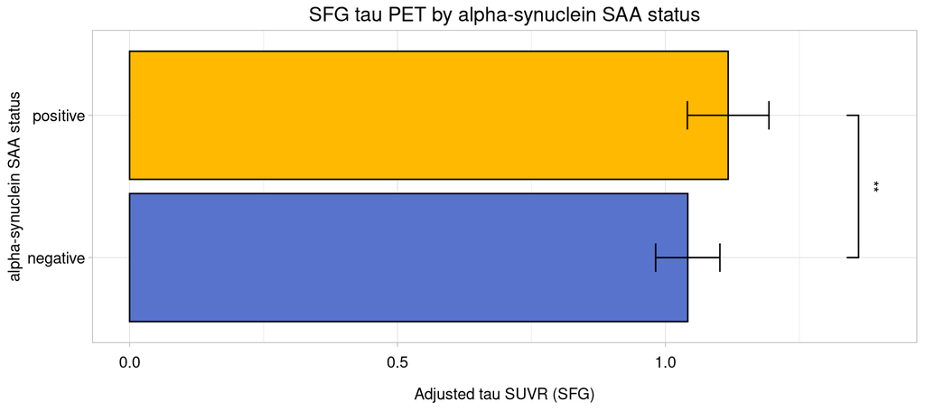

```r
sfig_ADNI <- ggplot(emm_df, aes(x = saa, y = emmean, fill = saa)) +
    geom_col(color = 'black') +
    scale_fill_manual(values = saa_colors) +
    geom_errorbar(aes(ymin = lower.CL, ymax = upper.CL), width = 0.2) +
    ggsignif::geom_signif(
        comparisons  = list(c('negative', 'positive')),
        annotations  = '**',
        y_position   = 1.35,
        tip_length   = 0.1
    ) +
    ylim(0, 1.4) +
    coord_flip() +
    labs(x = 'alpha-synuclein SAA status',
         y = 'Adjusted tau SUVR (SFG)',
         title = 'SFG tau PET by alpha-synuclein SAA status') +
    guides(fill = 'none') +
    theme_patch()
sfig_ADNI
```

```r
pdf('figure/Fig3_ADNI_tau_SAA.pdf', width = 9, height = 4)
sfig_ADNI
dev.off()
```

# 8 Sequential adjustment of the SAA-tau association

Estimate the SAA coefficient across sequential covariate sets:

```r
saa_coef <- function(m) {
    r <- summary(m)$coefficients['saapositive', ]
    data.frame(n = stats::nobs(m), beta = r[1], se = r[2], p = r[4])
}

models <- list(
    'Unadjusted'                         = lm(tau_sfg ~ saa, data = adni),
    '+ age, sex'                         = lm(tau_sfg ~ saa + age + sex, data = adni),
    '+ demographics (educ, APOE4, ancestry)' =
        lm(tau_sfg ~ saa + age + sex + education_yrs + APOE4_status + race_bin + ethnicity, data = adni),
    '+ amyloid SUVR (mediator)'          =
        lm(tau_sfg ~ saa + age + sex + education_yrs + APOE4_status + race_bin + ethnicity + amyloid_sfg, data = adni),
    '+ clinical stage (mediator)'        =
        lm(tau_sfg ~ saa + age + sex + education_yrs + APOE4_status + race_bin + ethnicity + dx, data = adni)
)

adj_tab <- purrr::map_dfr(models, saa_coef, .id = 'Model') %>%
    dplyr::mutate(dplyr::across(c(beta, se), ~ round(., 4)),
                  p = signif(p, 3))
knitr::kable(adj_tab, caption = 'SAA (positive vs negative) coefficient on SFG tau SUVR across adjustment sets.')
```

SAA (positive vs negative) coefficient on SFG tau SUVR across adjustment sets.

|  | Model | n | beta | se | p |
| --- | --- | --- | --- | --- | --- |
| Estimate…1 | Unadjusted | 369 | 0.0811 | 0.0287 | 0.00489 |
| Estimate…2 | + age, sex | 369 | 0.0967 | 0.0293 | 0.00105 |
| Estimate…3 | + demographics (educ, APOE4, ancestry) | 366 | 0.0754 | 0.0289 | 0.00952 |
| Estimate…4 | + amyloid SUVR (mediator) | 337 | 0.0634 | 0.0276 | 0.02220 |
| Estimate…5 | + clinical stage (mediator) | 366 | 0.0256 | 0.0268 | 0.34000 |

# 9 Amyloid burden and tau-SAA association

## 9.1 Amyloid SUVR by SAA status - adj. for age, sex

Model SFG amyloid SUVR by SAA status with age and sex as covariates.

```r
model_amyloid <- lm(amyloid_sfg ~ saa + age + sex, data = adni)
summary(model_amyloid)
```

```
##
## Call:
## lm(formula = amyloid_sfg ~ saa + age + sex, data = adni)
##
## Residuals:
##     Min      1Q  Median      3Q     Max
## -0.4499 -0.1991 -0.1016  0.1927  0.8057
##
## Coefficients:
##              Estimate Std. Error t value Pr(>|t|)
## (Intercept)  0.783077   0.140451   5.575 5.09e-08 ***
## saapositive  0.097420   0.039334   2.477  0.01375 *
## age          0.005613   0.001955   2.871  0.00435 **
## sexmale     -0.023631   0.030035  -0.787  0.43198
## ---
## Signif. codes:  0 '***' 0.001 '**' 0.01 '*' 0.05 '.' 0.1 ' ' 1
##
## Residual standard error: 0.2681 on 335 degrees of freedom
##   (30 observations deleted due to missingness)
## Multiple R-squared:  0.04964,    Adjusted R-squared:  0.04113
## F-statistic: 5.832 on 3 and 335 DF,  p-value: 0.0006801
```

```r
emm_amyloid <- as.data.frame(emmeans::emmeans(model_amyloid, ~ saa, type = 'response'))

p_amyloid <- ggplot(emm_amyloid, aes(x = saa, y = emmean, fill = saa)) +
    geom_col(color = 'black') +
    scale_fill_manual(values = saa_colors) +
    geom_errorbar(aes(ymin = lower.CL, ymax = upper.CL), width = 0.2) +
    coord_flip() +
        ggsignif::geom_signif(
        comparisons  = list(c('negative', 'positive')),
        annotations  = '*',
        y_position   = 1.35,
        tip_length   = 0.1
    ) +
    labs(x = 'alpha-synuclein SAA status',
         y = 'Adjusted amyloid SUVR (SFG)',
         title = 'SFG amyloid PET by alpha-synuclein SAA status',
         subtitle = 'adjusted for sex and age') +
    guides(fill = 'none') +
    theme_patch()
```

## 9.2 Amyloid SUVR by SAA status - full covariate set

```r
model_amyloid_adj <- lm(amyloid_sfg ~ saa + age + sex + education_yrs + APOE4_status +
                     race_bin + ethnicity, data = adni)
summary(model_amyloid_adj)
```

```
##
## Call:
## lm(formula = amyloid_sfg ~ saa + age + sex + education_yrs +
##     APOE4_status + race_bin + ethnicity, data = adni)
##
## Residuals:
##      Min       1Q   Median       3Q      Max
## -0.55909 -0.15156 -0.04254  0.12767  0.74827
##
## Coefficients:
##                                  Estimate Std. Error t value Pr(>|t|)
## (Intercept)                      0.661459   0.154393   4.284 2.41e-05 ***
## saapositive                      0.050455   0.034781   1.451  0.14783
## age                              0.007768   0.001774   4.379 1.61e-05 ***
## sexmale                          0.004460   0.026607   0.168  0.86697
## education_yrs                   -0.015582   0.005362  -2.906  0.00391 **
## APOE4_statusAPOE4.pos            0.256200   0.026418   9.698  < 2e-16 ***
## race_binwhite                    0.077494   0.044679   1.734  0.08377 .
## ethnicitynot_hispanic_or_latino  0.039874   0.067330   0.592  0.55411
## ---
## Signif. codes:  0 '***' 0.001 '**' 0.01 '*' 0.05 '.' 0.1 ' ' 1
##
## Residual standard error: 0.234 on 329 degrees of freedom
##   (32 observations deleted due to missingness)
## Multiple R-squared:  0.2809, Adjusted R-squared:  0.2656
## F-statistic: 18.36 on 7 and 329 DF,  p-value: < 2.2e-16
```

```r
emm_amyloid_adj <- as.data.frame(emmeans::emmeans(model_amyloid_adj, ~ saa, type = 'response'))

p_amyloid_adj <- ggplot(emm_amyloid_adj, aes(x = saa, y = emmean, fill = saa)) +
    geom_col(color = 'black') +
    scale_fill_manual(values = saa_colors) +
    geom_errorbar(aes(ymin = lower.CL, ymax = upper.CL), width = 0.2) +
    coord_flip() +
        ggsignif::geom_signif(
        comparisons  = list(c('negative', 'positive')),
        annotations  = 'n.s.',
        y_position   = 1.35,
        tip_length   = 0.1
    ) +
    labs(x = 'alpha-synuclein SAA status',
         y = 'Adjusted amyloid SUVR (SFG)',
         title = 'SFG amyloid PET by alpha-synuclein SAA status',
         subtitle = 'adjusted for age, sex, education, APOE4, race, and ethnicity') +
    guides(fill = 'none') +
    theme_patch()
```

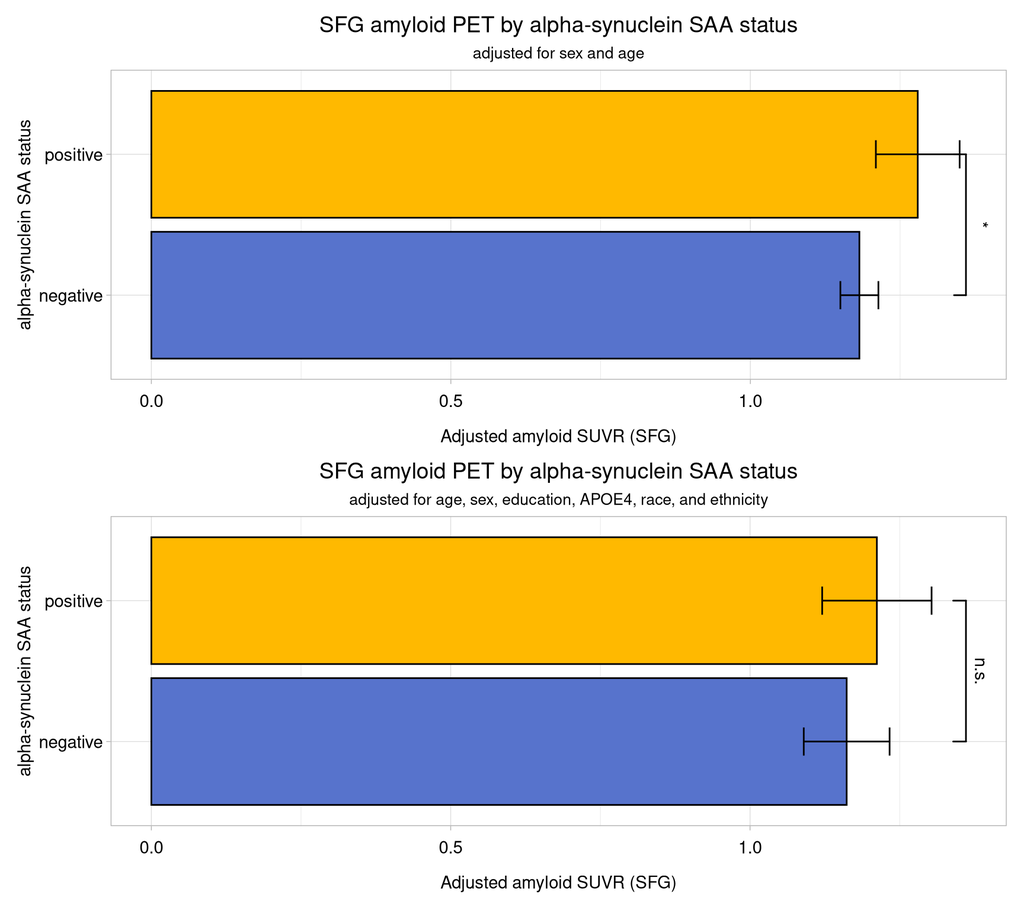

```r
p_amyloid / p_amyloid_adj
```

## 9.3 Tau model with amyloid covariate

Fit the tau-PET model with SFG amyloid SUVR added as a covariate.

```r
model_tau_amyloid <- lm(tau_sfg ~ saa + age + sex + education_yrs + APOE4_status +
                            race_bin + ethnicity + amyloid_sfg, data = adni)
summary(model_tau_amyloid)
```

```
##
## Call:
## lm(formula = tau_sfg ~ saa + age + sex + education_yrs + APOE4_status +
##     race_bin + ethnicity + amyloid_sfg, data = adni)
##
## Residuals:
##      Min       1Q   Median       3Q      Max
## -0.37670 -0.09236 -0.02406  0.05232  1.05009
##
## Coefficients:
##                                   Estimate Std. Error t value Pr(>|t|)
## (Intercept)                      0.9078644  0.1254059   7.239 3.22e-12 ***
## saapositive                      0.0633613  0.0275824   2.297 0.022239 *
## age                             -0.0054512  0.0014427  -3.778 0.000187 ***
## sexmale                         -0.0004203  0.0210337  -0.020 0.984071
## education_yrs                    0.0032896  0.0042928   0.766 0.444044
## APOE4_statusAPOE4.pos            0.0067672  0.0236810   0.286 0.775239
## race_binwhite                   -0.0057536  0.0354801  -0.162 0.871277
## ethnicitynot_hispanic_or_latino  0.0505245  0.0532531   0.949 0.343440
## amyloid_sfg                      0.3891396  0.0435817   8.929  < 2e-16 ***
## ---
## Signif. codes:  0 '***' 0.001 '**' 0.01 '*' 0.05 '.' 0.1 ' ' 1
##
## Residual standard error: 0.185 on 328 degrees of freedom
##   (32 observations deleted due to missingness)
## Multiple R-squared:  0.278,  Adjusted R-squared:  0.2604
## F-statistic: 15.78 on 8 and 328 DF,  p-value: < 2.2e-16
```

```r
emm_tau_adj <- as.data.frame(emmeans::emmeans(model_tau_amyloid, ~ saa, type = 'response'))

p_tau_adj <- ggplot(emm_tau_adj, aes(x = saa, y = emmean, fill = saa)) +
    geom_col(color = 'black') +
    scale_fill_manual(values = saa_colors) +
    geom_errorbar(aes(ymin = lower.CL, ymax = upper.CL), width = 0.2) +
        ggsignif::geom_signif(
        comparisons  = list(c('negative', 'positive')),
        annotations  = '*',
        y_position   = 1.35,
        tip_length   = 0.1
    ) +
    coord_flip() +
    labs(x = 'alpha-synuclein SAA status',
         y = 'Adjusted tau SUVR (SFG)',
         title = 'SFG tau PET by alpha-synuclein SAA status',
         subtitle = 'adjusted for sex, age, education, APOE4, race, ethnicity and amyloid SUVR') +
    guides(fill = 'none') +
    theme_patch()
```

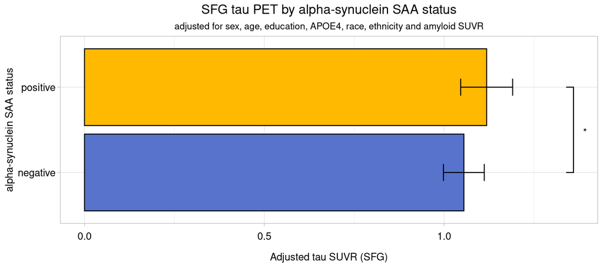

```r
p_tau_adj
```

```r
pdf('figure/SFig_ADNI_amyloid.pdf', width = 9, height = 8)
patchwork::wrap_plots(p_amyloid, p_amyloid_adj, ncol = 1)
dev.off()

pdf('figure/SFig_ADNI_tau_adj_amyloid.pdf', width = 9, height = 4)
p_tau_adj
dev.off()
```